# Human Activity Recognition

Adegboyega Yusuf Ajenifuja

24/10/2020

## PROJECT SUMMARY

Devices such as Jawbone Up, Nike FuelBand, and Fitbit now make it possible to collect a large amount of data about personal activity relatively inexpensively. People regularly quantify how much of a particular activity they do, but rarely quantify how well they do it. We shall utilize data from accelerometers on the belt, forearm, arm, and dumbell of 6 male participants aged between 20 and 28 years who were asked to perform barbell lifts correctly and incorrectly in 5 different ways. The goal of this project is to predict the manner in which the participants did the exercise. The manner is categorized as follows

1. (Class A), Performing the exercise exactly according to the specification
2. (Class B), throwing the elbows to the front
3. (Class C), lifting the dumbbell only halfway
4. (Class D), lowering the dumbbell only halfway
5. (Class E) and throwing the hips to the front

## METHODOLOGY

1 As stated in the project summary, we are trying to predict the manner in which the test subjects performed the exercises. This is represented by the “classe” variable which has 5 distinct values; letters A to E. That makes this a classification problem. We shall build our prediction model using Random Forest.

2. Using Cross Validation, we shall further split the provided training set into a training and test set in the ratio 75:25 so that the testing set provided will be used to validate our model
3. Model Building: this is a classification problem and we shall build our prediction algorithm using either random forest or decision trees and this will be heavily dependent on the number of predictors.
4. The out of sample error should be 1 less the accuracy of the prediction model when applied to the test set

## LOAD DATA

Exploring the data in a text editor shows that NA values are coded incorrectly. This we will rectify when loading in the data.

```r
training <- read.csv("http://d396qusza40orc.cloudfront.net/predmachlearn/pml-training.csv", na.strings = c("#DIV/0!", "", "NA"))
testing <- read.csv("http://d396qusza40orc.cloudfront.net/predmachlearn/pml-testing.csv", na.strings = c("#DIV/0!", "", "NA"))
```

## PARTITION TRAINING DATA INTO TRAINING AND TESTING SETS

Using cross validation, we shall further split the training set into a training and test set so that the provided test set acts as a validation set. the split shall be done in the ratio 75:25

```r
set.seed(2345)
train_part <- createDataPartition(training$classe, p = 0.75, list = FALSE)
train_sub <- training[train_part,]
test_sub  <- training[-train_part,]
```

## SOME PRELIMINARY DATA EXPLORATION ON TRAINING SET

```r
dim(train_sub)
dim(test_sub)
str(train_sub)
```

[output not shown]

```r
percent_na <- sapply(select(train_sub, !c(classe)), function(x) {(sum(is.na(x))/nrow(train_sub))*100})
data.frame(table(percent_na))
```

```
##          percent_na Freq
## 1                 0   59
## 2  97.9277075689632   67
## 3  97.9345019703764    1
## 4  97.9412963717896    1
## 5  97.9548851746161    1
## 6  97.9616795760294    4
## 7  97.9820627802691    3
## 8  97.9888571816823    4
## 9  98.0703899986411    2
## 10 98.3217828509308    1
## 11 98.3285772523441    2
## 12 98.3353716537573    8
## 13              100    6
```

Excluding the classe variable, we see that Only 59 variables have no NA values. All others have NA values in excess of 90% and in some cases 100%, well above the ideal threshold of 60%. We shall discard all columns from the training set with excessive number of NA values because if alternatively, we decide to replace the missing values using a method such as K nearest neighbours, the resulting values would not have enough variability thus making them near zero variables.

```r
names_train <- c(names(percent_na[percent_na < 90]), "classe")
train_sub <- train_sub[,names_train]
```

lets examine the data for near zero variables

```r
nearZeroVar(train_sub, saveMetrics = TRUE)
```

```
##                      freqRatio percentUnique zeroVar   nzv
## X                     1.000000  100.00000000   FALSE FALSE
## user_name             1.096096    0.04076641   FALSE FALSE
## raw_timestamp_part_1  1.000000    5.68691398   FALSE FALSE
## raw_timestamp_part_2  1.000000   88.91833130   FALSE FALSE
## cvtd_timestamp        1.026810    0.13588803   FALSE FALSE
## new_window           47.255738    0.01358880   FALSE  TRUE
## num_window            1.000000    5.82280201   FALSE FALSE
## roll_belt             1.118343    7.87471124   FALSE FALSE
## pitch_belt            1.083333   11.68637043   FALSE FALSE
## yaw_belt              1.048718   12.38619378   FALSE FALSE
## total_accel_belt      1.058459    0.19703764   FALSE FALSE
## gyros_belt_x          1.046287    0.87647778   FALSE FALSE
## gyros_belt_y          1.126878    0.46201930   FALSE FALSE
## gyros_belt_z          1.056338    1.12787063   FALSE FALSE
## accel_belt_x          1.074783    1.10069303   FALSE FALSE
## accel_belt_y          1.109672    0.91724419   FALSE FALSE
## accel_belt_z          1.040541    1.99755402   FALSE FALSE
## magnet_belt_x         1.054745    2.04511483   FALSE FALSE
## magnet_belt_y         1.127083    1.97717081   FALSE FALSE
## magnet_belt_z         1.017143    3.00991983   FALSE FALSE
## roll_arm             50.960000   16.65307786   FALSE FALSE
## pitch_arm            84.966667   19.48634325   FALSE FALSE
## yaw_arm              33.973333   18.21579019   FALSE FALSE
## total_accel_arm       1.023845    0.44843049   FALSE FALSE
## gyros_arm_x           1.061381    4.25329528   FALSE FALSE
## gyros_arm_y           1.384236    2.50033972   FALSE FALSE
## gyros_arm_z           1.225722    1.62386194   FALSE FALSE
## accel_arm_x           1.093750    5.19771708   FALSE FALSE
## accel_arm_y           1.071856    3.58064954   FALSE FALSE
## accel_arm_z           1.104167    5.25207229   FALSE FALSE
## magnet_arm_x          1.014085    9.02296508   FALSE FALSE
## magnet_arm_y          1.014493    5.81600761   FALSE FALSE
## magnet_arm_z          1.034884    8.53376818   FALSE FALSE
## roll_dumbbell         1.009804   86.05109390   FALSE FALSE
## pitch_dumbbell        2.349515   83.80214703   FALSE FALSE
## yaw_dumbbell          1.107527   85.46677538   FALSE FALSE
## total_accel_dumbbell  1.073314    0.27857046   FALSE FALSE
## gyros_dumbbell_x      1.032538    1.60347873   FALSE FALSE
## gyros_dumbbell_y      1.207289    1.82769398   FALSE FALSE
## gyros_dumbbell_z      1.017058    1.29093627   FALSE FALSE
## accel_dumbbell_x      1.008032    2.81288219   FALSE FALSE
## accel_dumbbell_y      1.100529    3.05748064   FALSE FALSE
## accel_dumbbell_z      1.229412    2.72455497   FALSE FALSE
## magnet_dumbbell_x     1.051471    7.29039272   FALSE FALSE
## magnet_dumbbell_y     1.259542    5.63255877   FALSE FALSE
## magnet_dumbbell_z     1.033557    4.51148254   FALSE FALSE
## roll_forearm         11.829960   13.15396114   FALSE FALSE
## pitch_forearm        57.254902   18.19540698   FALSE FALSE
## yaw_forearm          15.531915   12.29786656   FALSE FALSE
## total_accel_forearm   1.169381    0.44843049   FALSE FALSE
## gyros_forearm_x       1.069588    1.94999321   FALSE FALSE
## gyros_forearm_y       1.000000    4.93952983   FALSE FALSE
## gyros_forearm_z       1.214493    1.99075961   FALSE FALSE
## accel_forearm_x       1.104478    5.29283870   FALSE FALSE
## accel_forearm_y       1.102564    6.67210219   FALSE FALSE
## accel_forearm_z       1.058824    3.81165919   FALSE FALSE
## magnet_forearm_x      1.135593   10.02174208   FALSE FALSE
## magnet_forearm_y      1.190476   12.44054899   FALSE FALSE
## magnet_forearm_z      1.043478   11.07487430   FALSE FALSE
## classe                1.469452    0.03397201   FALSE FALSE
```

the “new_window” variable has been tagged a near Zero predictor but unfortunately, we can’t discard it because it’s a character variable which the “nearZeroVar” function is not optimized for.

A person’s name is highly unlikely to have any bearing on how well they perform an experiment so we shall discard the “user_name” variable. From the nearZeroVar output, it shows that all values of the “X” variable are unique. Lets make a plot of the variable to try and find out more about it.

```r
train_sub <- train_sub %>%
  select(!c(user_name))
```

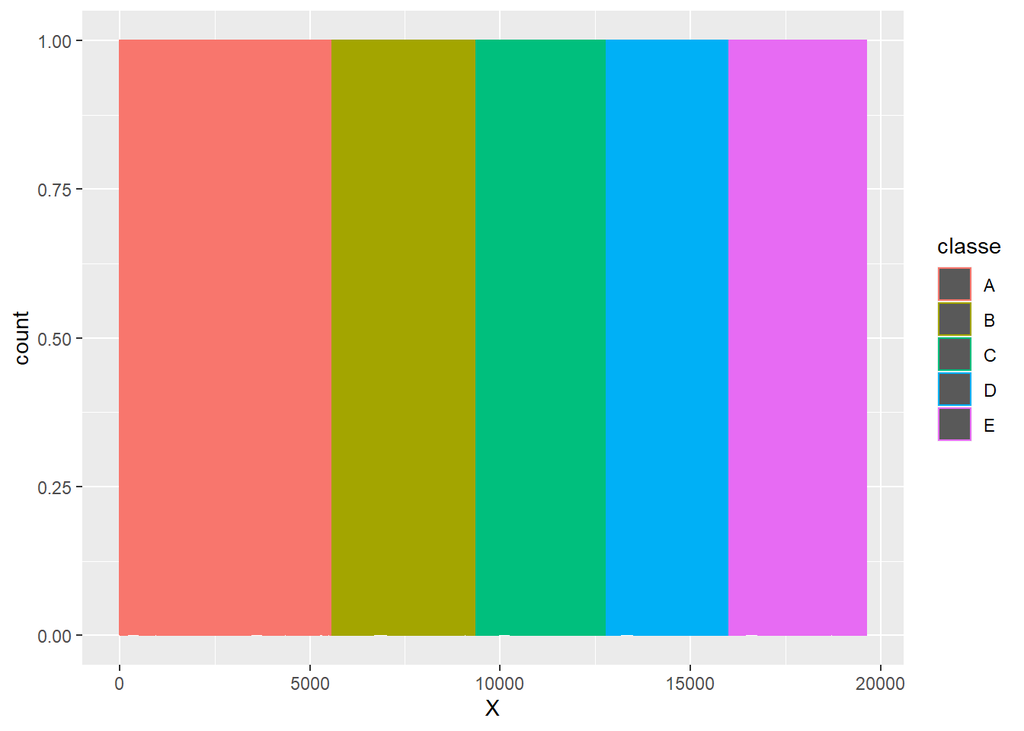

```r
ggplot(data = train_sub, mapping = aes(X)) + geom_bar(aes(color = classe))
```

The bar plot confirms that the X variable values are unique. Take a look at the range of values

```r
range(train_sub$X)
```

```
## [1]     1 19622
```

this is the number of rows in the initial training dataset. lets also take a look at the range of values in the initial training set as it appears this variable is merely a numbering of the rows

```r
range(training$X)
```

```
## [1]     1 19622
```

This confirms the suspicion that the X variable is a numbering of the rows in the dataset and we shall thus discard it.

```r
train_sub <- train_sub %>%
  select(!c(X))
```

## MODEL BUILDING

we are left with 57 possible predictors to build our model from which is still quite a lot. As such we shall utilize the intrinsic feature selection capabilities of the random forest algorithm for building our model. We shall also make use of parallel processing due to the number of variables available which could take some time.

```r
parallel1 <- makeCluster(detectCores() - 1) #this will assign all but 1 of the systems cores to our impending process, leaving 1 for the OS
registerDoParallel(parallel1)
```

```r
trContFit <- trainControl(method = "cv", number = 10, allowParallel = TRUE)
```

```r
fit1 <- train(classe ~ ., method = "rf", data = train_sub, trControl = trContFit)
```

we have trained the model and can now shut down the cluster

```r
stopCluster(parallel1)
registerDoSEQ()
```

lets view the model

```r
fit1
```

```
## Random Forest
##
## 14718 samples
##    57 predictor
##     5 classes: 'A', 'B', 'C', 'D', 'E'
##
## No pre-processing
## Resampling: Cross-Validated (10 fold)
## Summary of sample sizes: 13246, 13245, 13245, 13248, 13248, 13247, ...
## Resampling results across tuning parameters:
##
##   mtry  Accuracy   Kappa
##    2    0.9938164  0.9921771
##   38    0.9991848  0.9989689
##   75    0.9986413  0.9982815
##
## Accuracy was used to select the optimal model using the largest value.
## The final value used for the model was mtry = 38.
```

```r
fit1$finalModel
```

```
##
## Call:
##  randomForest(x = x, y = y, mtry = param$mtry)
##                Type of random forest: classification
##                      Number of trees: 500
## No. of variables tried at each split: 38
##
##         OOB estimate of  error rate: 0.08%
## Confusion matrix:
##      A    B    C    D    E  class.error
## A 4185    0    0    0    0 0.0000000000
## B    1 2845    2    0    0 0.0010533708
## C    0    3 2564    0    0 0.0011686794
## D    0    0    2 2408    2 0.0016583748
## E    0    0    0    2 2704 0.0007390983
```

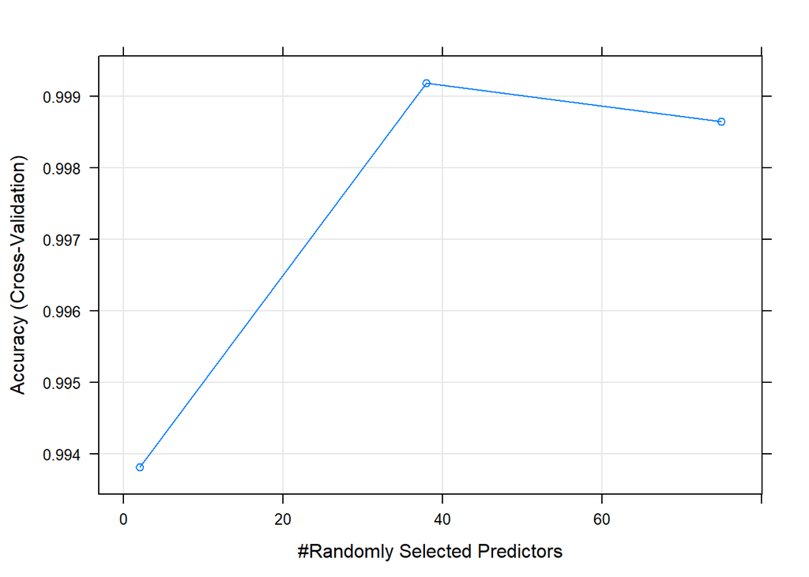

```r
plot(fit1)
```

we see that the optimal model was selected using 38 predictors. According to the plot, the accuracy is between 0.9938 and 0.9992 and as stated, it peaks at 38 variables We shall now predict on the test_sub dataset, generate a confusion matrix and attempt to compute the out of sample error

```r
pred_test <- predict(fit1, test_sub)
confMat <- confusionMatrix(pred_test, as.factor(test_sub$classe))
confMat
```

```
## Confusion Matrix and Statistics
##
##           Reference
## Prediction    A    B    C    D    E
##          A 1395    5    0    0    0
##          B    0  944    0    0    0
##          C    0    0  855    3    0
##          D    0    0    0  797    0
##          E    0    0    0    4  901
##
## Overall Statistics
##
##                Accuracy : 0.9976
##                  95% CI : (0.9957, 0.9987)
##     No Information Rate : 0.2845
##     P-Value [Acc > NIR] : < 2.2e-16
##
##                   Kappa : 0.9969
##
##  Mcnemar's Test P-Value : NA
##
## Statistics by Class:
##
##                      Class: A Class: B Class: C Class: D Class: E
## Sensitivity            1.0000   0.9947   1.0000   0.9913   1.0000
## Specificity            0.9986   1.0000   0.9993   1.0000   0.9990
## Pos Pred Value         0.9964   1.0000   0.9965   1.0000   0.9956
## Neg Pred Value         1.0000   0.9987   1.0000   0.9983   1.0000
## Prevalence             0.2845   0.1935   0.1743   0.1639   0.1837
## Detection Rate         0.2845   0.1925   0.1743   0.1625   0.1837
## Detection Prevalence   0.2855   0.1925   0.1750   0.1625   0.1845
## Balanced Accuracy      0.9993   0.9974   0.9996   0.9956   0.9995
```

the out of sample error is defined by the proportion of incorrectly predicted samples within the entire sample data which works out to be 1 minus the accuracy (0.9976)

```r
1-0.9976
```

```
## [1] 0.0024
```